Plan projektu klasyfikacji zbioru danych IRIS

# Zadanie 1

## Przygotowanie i zbadanie danych

Wczytujemy zbiór danych IRIS. Wykonujemy podstawową analizę danych aby zrozumieć strukturę zbioru danych, w tym liczbę próbek, cechy oraz ich typy.

```python
import pandas as pd

# Wczytujemy zbiór danych
iris_data = pd.read_csv('https://raw.githubusercontent.com/uiuc-cse/data-fa14/gh-pages/data/iris.csv')

# Wyświetlamy podstawowe informacje o zbiorze danych
print(iris_data.info())

# Wyświetlamy podstawowe statystyki zbioru danych
print(iris_data.describe())

# Wyświetlamy pierwsze 5 próbek ze zbioru danych
print(iris_data.head())
```

```
<class 'pandas.core.frame.DataFrame'>
RangeIndex: 150 entries, 0 to 149
Data columns (total 5 columns):
 #   Column        Non-Null Count  Dtype
---  ------        --------------  -----
 0   sepal_length  150 non-null    float64
 1   sepal_width   150 non-null    float64
 2   petal_length  150 non-null    float64
 3   petal_width   150 non-null    float64
 4   species       150 non-null    object
dtypes: float64(4), object(1)
memory usage: 6.0+ KB
None
       sepal_length  sepal_width  petal_length  petal_width
count    150.000000   150.000000    150.000000   150.000000
mean       5.843333     3.054000      3.758667     1.198667
std        0.828066     0.433594      1.764420     0.763161
min        4.300000     2.000000      1.000000     0.100000
25%        5.100000     2.800000      1.600000     0.300000
50%        5.800000     3.000000      4.350000     1.300000
75%        6.400000     3.300000      5.100000     1.800000
max        7.900000     4.400000      6.900000     2.500000
   sepal_length  sepal_width  petal_length  petal_width species
0           5.1          3.5           1.4          0.2  setosa
1           4.9          3.0           1.4          0.2  setosa
2           4.7          3.2           1.3          0.2  setosa
3           4.6          3.1           1.5          0.2  setosa
4           5.0          3.6           1.4          0.2  setosa
```

Zastosuj różne metody wizualizacji danych, takie jak wykresy punktowe, histogramy cech, a także wykresy pudełkowe, aby zobaczyć rozkład danych i ewentualne zależności między cechami.

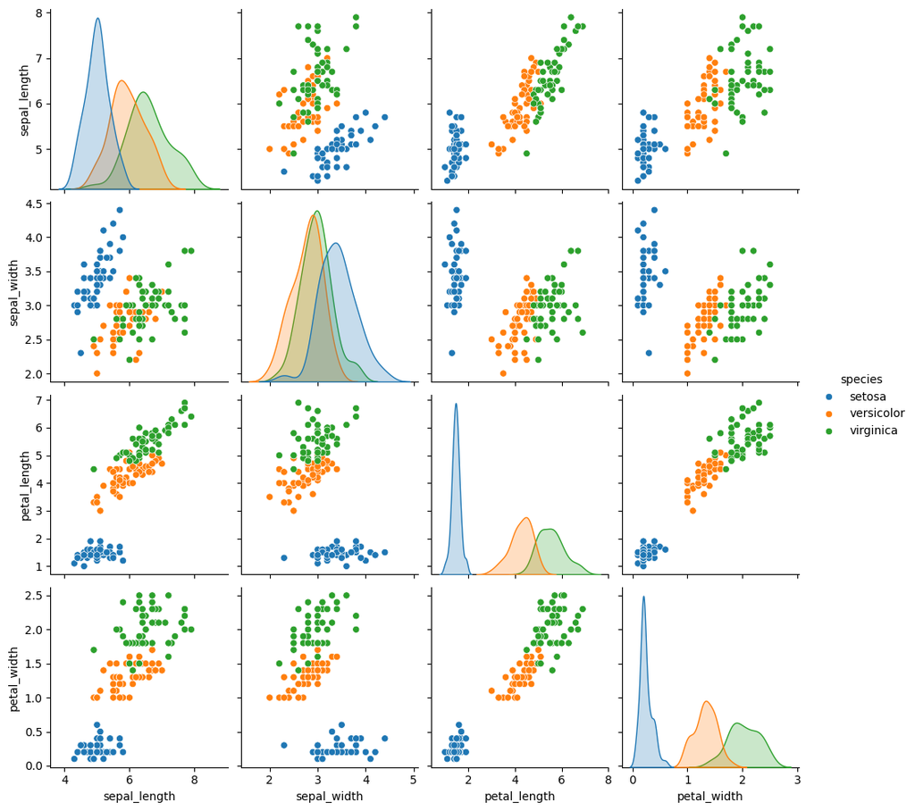

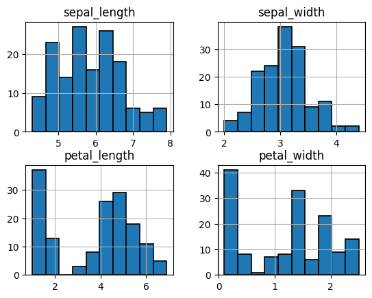

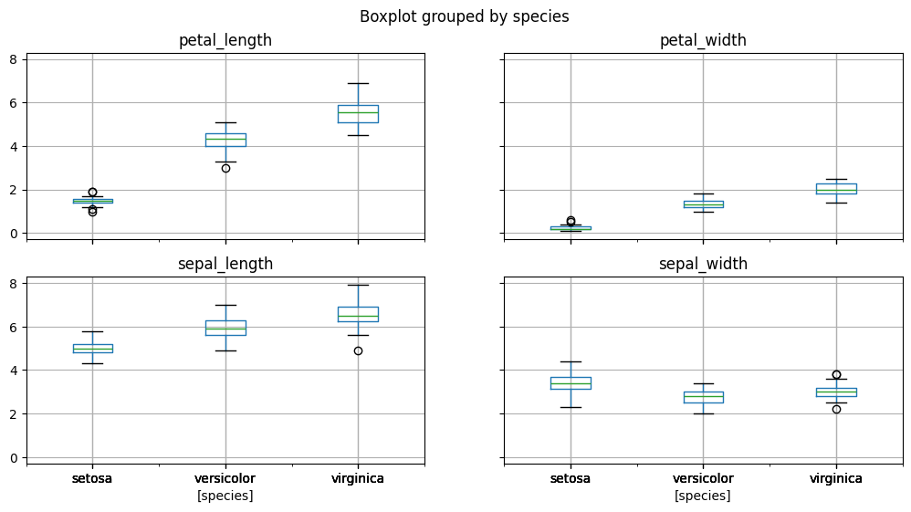

```python
import matplotlib.pyplot as plt
import seaborn as sns

# Wczytujemy zbiór danych
iris_data = pd.read_csv('https://raw.githubusercontent.com/uiuc-cse/data-fa14/gh-pages/data/iris.csv')

# Wykres punktowy
sns.pairplot(iris_data, hue='species')
plt.show()

# Histogramy cech
iris_data.hist(edgecolor='black', linewidth=1.2)
plt.show()

# Wykresy pudełkowe
iris_data.boxplot(by='species', figsize=(12, 6))
plt.show()
```

Sprawdzenie brakujących danych, duplikatów itp. Normalizacja, standaryzacja danych. Podział danych na zbiór uczący i testowy.

```python
from sklearn.model_selection import train_test_split
from sklearn.preprocessing import StandardScaler

# Wczytujemy zbiór danych
iris_data = pd.read_csv('https://raw.githubusercontent.com/uiuc-cse/data-fa14/gh-pages/data/iris.csv')

# Sprawdzamy brakujące dane
print(iris_data.isnull().sum())

# Sprawdzamy duplikaty
print(iris_data.duplicated().sum())

# Usuwamy duplikaty
iris_data = iris_data.drop_duplicates()

# Normalizacja i standaryzacja danych
scaler = StandardScaler()
iris_data[['sepal_length', 'sepal_width', 'petal_length', 'petal_width']] = scaler.fit_transform(iris_data[['sepal_length', 'sepal_width', 'petal_length', 'petal_width']])

# Podział danych na zbiór uczący i testowy
X = iris_data[['sepal_length', 'sepal_width', 'petal_length', 'petal_width']]
y = iris_data['species']
X_train, X_test, y_train, y_test = train_test_split(X, y, test_size=0.2, random_state=42)

print(X_train.head())
```

```
sepal_length    0
sepal_width     0
petal_length    0
petal_width     0
species         0
dtype: int64
3
     sepal_length  sepal_width  petal_length  petal_width
137      0.657817     0.101529      0.980954     0.782686
47      -1.520635     0.331139     -1.357737    -1.335700
121     -0.310384    -0.587304      0.638707     1.047484
27      -0.794484     1.019971     -1.300696    -1.335700
4       -1.036535     1.249582     -1.357737    -1.335700
```

## Wnioski:

Podczas analizy zbioru danych IRIS, wykonałem kilka kroków, które pomogły mi zrozumieć strukturę i charakterystyki danych. Oto kilka moich wniosków i obserwacji:

1. Zbiór danych IRIS składa się z 150 próbek, z których każda ma 4 cechy: długość i szerokość płatków oraz długość i szerokość kielicha. Każda próbka jest przypisana do jednego z trzech gatunków irysów.
2. Wykresy punktowe i histogramy pomogły mi zrozumieć rozkład cech i zależności między nimi. Na przykład, wykres punktowy pokazał, że długość i szerokość płatków są silnie skorelowane.
3. Sprawdziłem, czy w danych są jakiekolwiek brakujące wartości lub duplikaty. W moim przypadku, nie było żadnych brakujących wartości, ale znalazłem kilka duplikatów, które usunąłem.
4. Dane zostały znormalizowane i standaryzowane, co jest ważnym krokiem w przygotowaniu danych do wielu algorytmów uczenia maszynowego.
5. Na koniec, podzieliłem dane na zbiór uczący i testowy. To pozwoli mi na trenowanie i testowanie modelu na różnych zestawach danych, co jest kluczowe dla oceny wydajności modelu.